# EATING ATTITUDE AND HEALTHY LIFE SURVEY ANALYSIS

## INTRODUCTION

The aim of this study is to determine the eating attitudes of the people and their orientation towards healthy living. Eating attitudes are examined in terms of the demographic characteristics of the people. In this questionnaire, the attitudes of people were examined in terms of gender, age, education level, marital status, and region of residence.

## DESRIPTION OF PROBLEM

Accurate eating habits gained at a young age can prevent or reduce the diseases encountered in later ages. Orientation to a healthy life should be the priority of all people. The general purpose of this project is eating attitudes.

## DESRIPTION OF DATA

As a result of a 30-person survey, we have 30 objects and 14 variables. We have 5 demographic variables. These; gender, age, educational status, material status, region

## PROGRESS

Manipulation: The whole data set was digitized. that;

always = 4, often = 3, sometimes = 2, never = 1

All demographic values has changed as factor.

As final, SUM column added for analyzing survey success.

```r
MyData <- read.csv(file="C:/Users/Hp/Desktop/Survey_datas.csv", header=T, sep=",")
MyData$AGE = cut(MyData$AGE, breaks = c(0,35,50),labels = c("YOUNG","OLD"))

Sum= data.frame(MyData$Q1+MyData$Q2+MyData$Q4+MyData$Q5+MyData$Q6+MyData$Q7+MyData$Q8+MyData$Q9)
colnames(Sum)=c("SUM")
MyData = cbind(MyData,Sum)
```

## Including Plots

Survey data were analyzed using plots, for example:

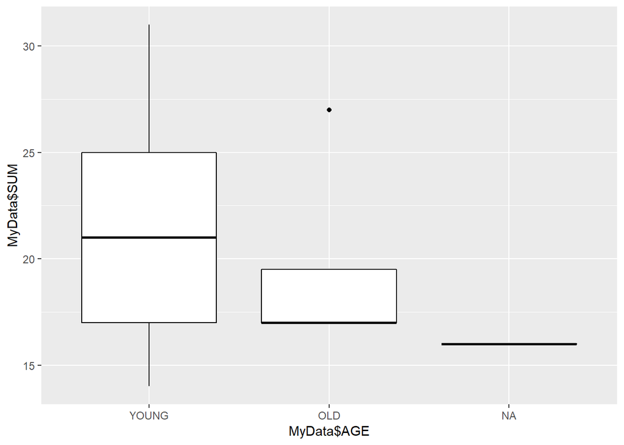

```r
library(ggplot2)

ggplot(MyData, aes(x = MyData$AGE , y = MyData$SUM)) +
  geom_boxplot(color="black")
```

In this graph, it seems when age is increase, the success of survey is decrease.

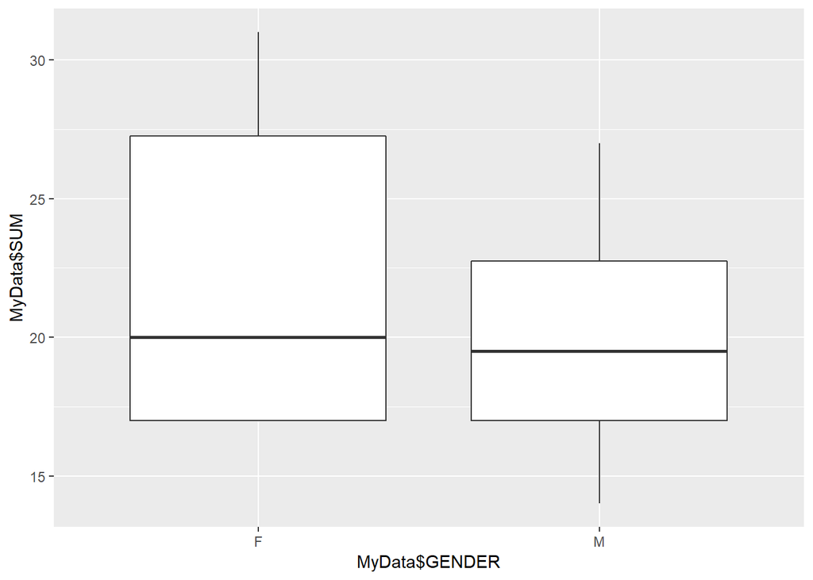

```r
qplot(x=MyData$GENDER,y=MyData$SUM,
      geom = "boxplot", data = MyData
      )
```

In this graph, it seems fameles are more successful than males.We can say that females are trying live healthy more than males.

## ONE SAMPLE T-TEST

One sample t-test for ???SUM??? which is rowsam of survey results. Lets assume that the mean is 20 a) Ho = m1=20 Ha = m1 > 20 b) Test the hypothesis for 95% confidence level:

```r
mean(MyData$SUM)
```

```
## [1] 20.66667
```

```r
t.test(MyData$SUM,alternative = "greater", mu = 20)
```

```
##
##  One Sample t-test
##
## data:  MyData$SUM
## t = 0.78551, df = 29, p-value = 0.2193
## alternative hypothesis: true mean is greater than 20
## 95 percent confidence interval:
##  19.2246     Inf
## sample estimates:
## mean of x
##  20.66667
```

## TWO SAMPLE T-TEST

1)GENDER

```r
t.test(MyData$SUM~GENDER, data=MyData)
```

```
##
##  Welch Two Sample t-test
##
## data:  MyData$SUM by GENDER
## t = 0.99148, df = 19.574, p-value = 0.3336
## alternative hypothesis: true difference in means is not equal to 0
## 95 percent confidence interval:
##  -1.998461  5.609572
## sample estimates:
## mean in group F mean in group M
##        21.75000        19.94444
```

p-value > 0,005 ??? Not reject null hypothesis.

2)AGE

```r
t.test(MyData$SUM~AGE, data=MyData)
```

```
##
##  Welch Two Sample t-test
##
## data:  MyData$SUM by AGE
## t = 0.57721, df = 3.8821, p-value = 0.5956
## alternative hypothesis: true difference in means is not equal to 0
## 95 percent confidence interval:
##  -5.957175  9.037175
## sample estimates:
## mean in group YOUNG   mean in group OLD
##               21.04               19.50
```

p-value > 0,005 ??? Not reject null hypothesis.

## ANOVA

1)EDUCATION

```r
output <- aov(MyData$SUM~EDUCATION, data=MyData)
summary(output)
```

```
##             Df Sum Sq Mean Sq F value Pr(>F)
## EDUCATION    2   47.8   23.90   1.115  0.343
## Residuals   27  578.9   21.44
```

```r
TukeyHSD(output)
```

```
##   Tukey multiple comparisons of means
##     95% family-wise confidence level
##
## Fit: aov(formula = MyData$SUM ~ EDUCATION, data = MyData)
##
## $EDUCATION
##               diff        lwr       upr     p adj
## PRI-HIGH -3.000000 -15.400282  9.400282 0.8213744
## UNI-HIGH  2.304348  -2.958461  7.567157 0.5309559
## UNI-PRI   5.304348  -6.423002 17.031697 0.5094595
```

It seems that these 3 groups are same.

2)REGION

```r
output2 <- aov(MyData$SUM~REGION, data=MyData)
summary(output2)
```

```
##             Df Sum Sq Mean Sq F value Pr(>F)
## REGION       2  111.8   55.92   2.933 0.0704 .
## Residuals   27  514.8   19.07
## ---
## Signif. codes:  0 '***' 0.001 '**' 0.01 '*' 0.05 '.' 0.1 ' ' 1
```

```r
TukeyHSD(output2)
```

```
##   Tukey multiple comparisons of means
##     95% family-wise confidence level
##
## Fit: aov(formula = MyData$SUM ~ REGION, data = MyData)
##
## $REGION
##           diff        lwr        upr     p adj
## EGE-ANA  3.625  -7.424993 14.6749932 0.6980947
## MAR-ANA -1.400 -13.260097 10.4600973 0.9539582
## MAR-EGE -5.025 -10.347382  0.2973815 0.0670163
```

It seems that these 3 groups are same.

## CONCLUSION

As a result, people’s eating attitudes and orientations towards healthy living were examined according to factors.

## APPEND

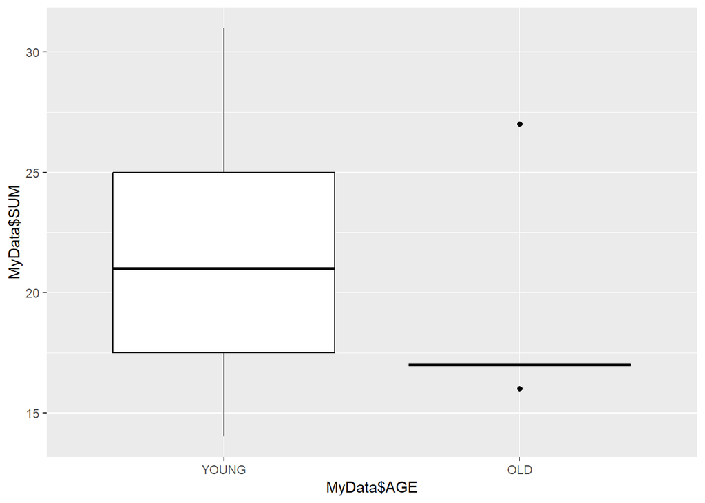

```r
MyData <- read.csv(file="C:/Users/Hp/Desktop/Survey_datas.csv", header=T, sep=",")
MyData$AGE = cut(MyData$AGE, breaks = c(15,30,80),labels = c("YOUNG","OLD"))

Sum= data.frame(MyData$Q1+MyData$Q2+MyData$Q4+MyData$Q5+MyData$Q6+MyData$Q7+MyData$Q8+MyData$Q9)
colnames(Sum)=c("SUM")
MyData = cbind(MyData,Sum)



library(ggplot2)

ggplot(MyData, aes(x = MyData$AGE , y = MyData$SUM)) +
  geom_boxplot(color="black")
```

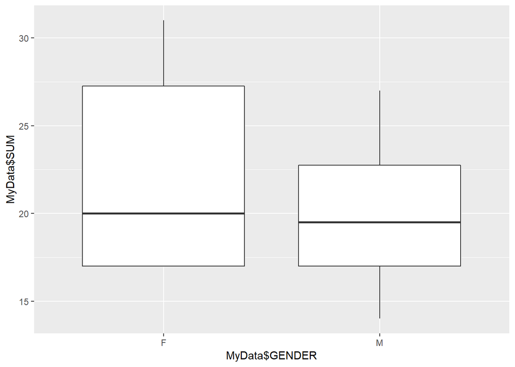

```r
qplot(x=MyData$GENDER,y=MyData$SUM,
      geom = "boxplot", data = MyData
      )
```

```r
t.test(MyData$SUM~GENDER, data=MyData)
```

```
##
##  Welch Two Sample t-test
##
## data:  MyData$SUM by GENDER
## t = 0.99148, df = 19.574, p-value = 0.3336
## alternative hypothesis: true difference in means is not equal to 0
## 95 percent confidence interval:
##  -1.998461  5.609572
## sample estimates:
## mean in group F mean in group M
##        21.75000        19.94444
```

```r
t.test(MyData$SUM~AGE, data=MyData)
```

```
##
##  Welch Two Sample t-test
##
## data:  MyData$SUM by AGE
## t = 1.7671, df = 11.963, p-value = 0.1027
## alternative hypothesis: true difference in means is not equal to 0
## 95 percent confidence interval:
##  -0.724918  6.936098
## sample estimates:
## mean in group YOUNG   mean in group OLD
##            21.39130            18.28571
```

```r
output <- aov(MyData$SUM~EDUCATION, data=MyData)
summary(output)
```

```
##             Df Sum Sq Mean Sq F value Pr(>F)
## EDUCATION    2   47.8   23.90   1.115  0.343
## Residuals   27  578.9   21.44
```

```r
TukeyHSD(output)
```

```
##   Tukey multiple comparisons of means
##     95% family-wise confidence level
##
## Fit: aov(formula = MyData$SUM ~ EDUCATION, data = MyData)
##
## $EDUCATION
##               diff        lwr       upr     p adj
## PRI-HIGH -3.000000 -15.400282  9.400282 0.8213744
## UNI-HIGH  2.304348  -2.958461  7.567157 0.5309559
## UNI-PRI   5.304348  -6.423002 17.031697 0.5094595
```

```r
output2 <- aov(MyData$SUM~REGION, data=MyData)
summary(output2)
```

```
##             Df Sum Sq Mean Sq F value Pr(>F)
## REGION       2  111.8   55.92   2.933 0.0704 .
## Residuals   27  514.8   19.07
## ---
## Signif. codes:  0 '***' 0.001 '**' 0.01 '*' 0.05 '.' 0.1 ' ' 1
```

```r
TukeyHSD(output2)
```

```
##   Tukey multiple comparisons of means
##     95% family-wise confidence level
##
## Fit: aov(formula = MyData$SUM ~ REGION, data = MyData)
##
## $REGION
##           diff        lwr        upr     p adj
## EGE-ANA  3.625  -7.424993 14.6749932 0.6980947
## MAR-ANA -1.400 -13.260097 10.4600973 0.9539582
## MAR-EGE -5.025 -10.347382  0.2973815 0.0670163
```